# DAG

Shadi

2023-06-20

### Causal Structure Discovery

I utilized causal structure discovery techniques to accurately represent the data generating process and unveil the underlying causal relationships among the variables. The causal structure discovery approach identifies potential causal relationships based on patterns and dependencies observed in the data. The resulting Directed Acyclic Graph (DAG) from the causal discovery is capturing the complex interplay between the variables, accounting for confounding factors and potential biases, and providing credible evidence for the causal effects of medicaid expansion on medicaid take-up and uninsured rate.

By utilizing the DAG obtained through the causal discovery approach, I can conduct backdoor and front door analyses, enabling the identification of the minimal adjustment set. The minimal adjustment set represents the smallest subset of variables that must be controled for to obtain unbiased estimates of causal effects.

In the initial phase of our analysis, a DAG , as shown in Graph 1, was generated using multiple constraint-based and score-based algorithms including GDS algorithms, Greedy Equivalence Search (GES), Peter-Clark (PC) algorithm, and Fast Causal Inferences (FCI). To integrate the information obtained from these algorithms, following Joe et al.(2023) I employed a majority voting approach. This involved considering each edge and determining its presence in the final graph based on whether it appeared in more than 50% of the cases, indicating agreement among the majority of the algorithms.

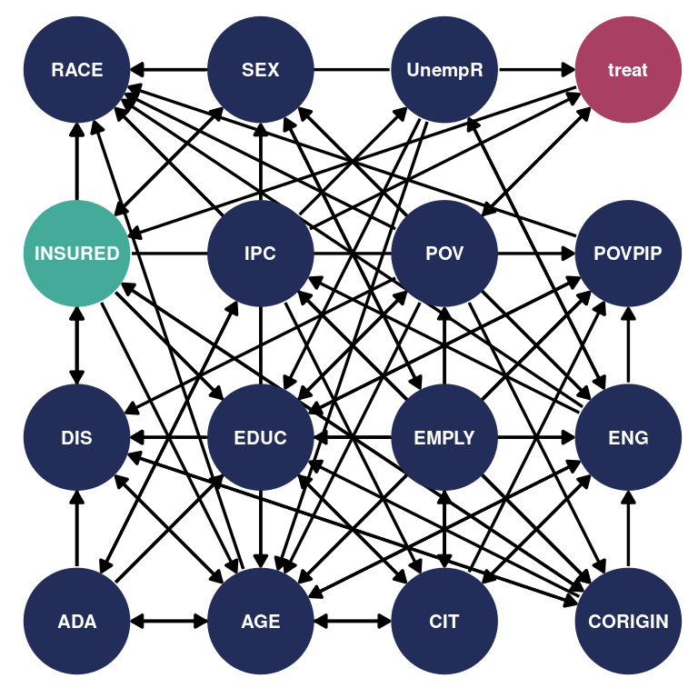

### Revised casual graph

To enhance the accuracy of the causal relationships represented in the DAG, I carefully reviewed and manually edited the graph by removing paths that contradicted my domain knowledge or appeared implausible within the context. By applying these revisions, the resulting DAG, illustrated in graph 2, aligns more closely with my expertise in the field and provides a more trustworthy representation of the underlying causal structure in my analysis.

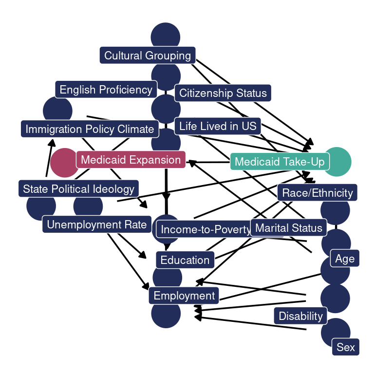

### Minimal adjustment set

The identified causal relationship between Medicaid expansion and Medicaid take-up in the revised DAG provides compelling evidence that changes in the treatment variable directly influence changes in the outcome variable. This finding suggests that interventions targeting the treatment variable, such as expanding Medicaid coverage, can potentially have a substantial impact on improving the rate of Medicaid take-up.

by conducting backdoor analysis I identified the necessary adjustment set, revealing that variables Citizenship Status, Immigration Policy Climate, Unemployment Rate need to be controlled for to accurately estimate the causal effect between Medicaid expansion and Medicaid take-up.

```r
adjustmentSets(findag)
```

```
## { Citizenship Status, Immigration Policy Climate, Unemployment Rate }
## { State Political Ideology, Unemployment Rate }
```

### Simplified causal graph

To enhance the clarity and interpretability of the graph, I employed a strategy to simplify its complexity. This involved grouping related variables into single nodes, such as combining ‘education,’ ‘income,’ and ‘employment’ into a unified node labeled ‘Socioeconomic.’ The streamlined representation of the underlying relationships can be observed in Graph 3.

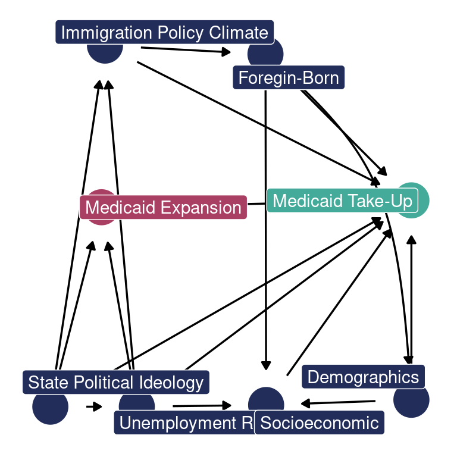

Although utilizing causal discovery algorithms has limitations, such as assuming the adequacy of observed variables and relying on the absence of unobserved confounders, efforts were made to include relevant variables in the analysis. However, it is possible that unmeasured confounders may exist, potentially introducing biases into the identified causal relationships. Therefore, the obtained graph may not precisely represent the true underlying causal structure..

Due to these limitations, I do not solely rely on this graph and its suggested adjustment set for estimating causal effects in my analysis. Nonetheless, the DAG derived from the causal discovery approach serves as a valuable tool for generating hypotheses and guiding the modeling process, as well as informing the selection of control variables in my DID approach analysis.